# Entregable 3

Armando Sebastian Villalobos Blass

16/6/2022

La educación en el mundo es un factor importante para el desarrollo de los países debido a que es la base de todo niño y adolescente y permite que se desarrollen de manera eficiente en diferentes ámbitos como por ejemplo el laboral.

El objetivo de este análisis es saber cuantos jóvenes en etapa secundaria se encuentran inscritos en los colegios y si esto es afectado por factores como el gasto que realizan los estados para la educación y si el nivel pobreza afecta la continuación escolar.

La variable dependiente es el porcentaje de de inscripción escolar secundaria neta por país, porque este se encuentra afectado o influenciado por el PBI de los países, el gasto por parte del estado en educación y la pobreza de la población.

Para el caso del PBI esta variable independiente se sustenta porque, según el IPE, la medición del PBI por ingresos, es decir, las remuneraciones pagos de impuestos, el consumo de capital fijo, entre otros, permite saber cuánto el estado puede recaudar para ejecutar de manera óptima en el mejoramiento de un país, en este caso, la educación.

En cuanto al gasto en educación por parte del estado, según el Banco Mundial, es diferente en distintos países por factores como el nivel de desarrollo que ellos poseen y el nivel de eficiencia que tienen los estados para ejecutar de manera correcta los presupuestos para la educación.

Por último, el nivl de pobreza, según el portal “el diaro de la educación”, resalta que el impacto de la pobreza en el rendimiento escolar y puede producir fracaso escolar, más pobreza y exclusión social por no poseer educación mínima y no estar calificado para un trabajo de calidad que les permita salir de la pobreza.

Modelo lineal 1: En esta primera hipótesis plasmado en este modelo lineal, veremos cómo el porcentaje de de inscripción escolar secundaria neta por país (Matricula) es afectado por el PBI per cápita POR país (PBIPC) y el porcentaje de inversión del Estado en Educación POR país (gastoedu).

```r
modelo1=formula(Matricula~PBIPC+gastoedu)
library(stargazer)
hip1=lm(modelo1,data=data1)
stargazer(hip1,type = "text",intercept.bottom = FALSE)
```

```
##
## ===============================================
##                         Dependent variable:
##                     ---------------------------
##                              Matricula
## -----------------------------------------------
## Constant                     49.702***
##                               (7.718)
##
## PBIPC                        0.001***
##                              (0.0001)
##
## gastoedu                       1.999
##                               (1.768)
##
## -----------------------------------------------
## Observations                    95
## R2                             0.303
## Adjusted R2                    0.288
## Residual Std. Error      21.815 (df = 92)
## F Statistic           19.980*** (df = 2; 92)
## ===============================================
## Note:               *p<0.1; **p<0.05; ***p<0.01
```

```r
summary(hip1)
```

```
##
## Call:
## lm(formula = modelo1, data = data1)
##
## Residuals:
##     Min      1Q  Median      3Q     Max
## -47.941 -19.587   4.466  17.225  36.972
##
## Coefficients:
##              Estimate Std. Error t value Pr(>|t|)
## (Intercept) 4.970e+01  7.718e+00   6.440 5.37e-09 ***
## PBIPC       7.834e-04  1.451e-04   5.400 5.19e-07 ***
## gastoedu    1.999e+00  1.768e+00   1.131    0.261
## ---
## Signif. codes:  0 '***' 0.001 '**' 0.01 '*' 0.05 '.' 0.1 ' ' 1
##
## Residual standard error: 21.82 on 92 degrees of freedom
## Multiple R-squared:  0.3028, Adjusted R-squared:  0.2877
## F-statistic: 19.98 on 2 and 92 DF,  p-value: 6.223e-08
```

Modelo lineal 2: En esta segunda hipótesis plasmado en este modelo lineal, veremos cómo el porcentaje de de inscripción escolar secundaria neta por país (Matricula) es afectado por el PBI per cápita POR país (PBIPC) y el porcentaje de inversión del Estado en Educación POR país (gastoedu), controlado ambas variables por el porcentaje de la población que se encuentra por debajo de la línea de pobreza por país (Pobreza).

```r
modelo2=formula(Matricula~PBIPC+Pobreza+gastoedu)
hip2=lm(modelo2,data=data1)
stargazer(hip2,type = "text",intercept.bottom = FALSE)
```

```
##
## ===============================================
##                         Dependent variable:
##                     ---------------------------
##                              Matricula
## -----------------------------------------------
## Constant                     81.421***
##                               (7.131)
##
## PBIPC                        0.0004***
##                              (0.0001)
##
## Pobreza                      -0.924***
##                               (0.115)
##
## gastoedu                       1.765
##                               (1.360)
##
## -----------------------------------------------
## Observations                    95
## R2                             0.592
## Adjusted R2                    0.578
## Residual Std. Error      16.781 (df = 91)
## F Statistic           44.002*** (df = 3; 91)
## ===============================================
## Note:               *p<0.1; **p<0.05; ***p<0.01
```

```r
summary(hip2)
```

```
##
## Call:
## lm(formula = modelo2, data = data1)
##
## Residuals:
##     Min      1Q  Median      3Q     Max
## -43.635 -10.405   0.813  12.431  30.519
##
## Coefficients:
##               Estimate Std. Error t value Pr(>|t|)
## (Intercept) 81.4214544  7.1312123  11.418  < 2e-16 ***
## PBIPC        0.0003700  0.0001229   3.010  0.00338 **
## Pobreza     -0.9236185  0.1150249  -8.030 3.32e-12 ***
## gastoedu     1.7649300  1.3601977   1.298  0.19772
## ---
## Signif. codes:  0 '***' 0.001 '**' 0.01 '*' 0.05 '.' 0.1 ' ' 1
##
## Residual standard error: 16.78 on 91 degrees of freedom
## Multiple R-squared:  0.5919, Adjusted R-squared:  0.5785
## F-statistic:    44 on 3 and 91 DF,  p-value: < 2.2e-16
```

Asimismo, notamos que hay una variación de un modelo a otro del valor del Residual Standar Error (RSE). La comparación de modelos usando la tabla de análisis de varianza (t-anova) propone como hipótesis nula que los modelos no difieren (no se ha reducido el error al pasar de un modelo al otro). Como la comparación es significativa (viendo el Pr(>F)), rechazamos igualdad de modelos En conclusión, el modelo 2 es la más óptima al reducir el error incluyendo una variable adicional.

Prueba T-Anova

```r
tanova=anova(hip1,hip2)
stargazer(tanova,type = 'text',summary = F,title = "Table de Análisis de Varianza")
```

```
##
## Table de Análisis de Varianza
## ================================================
##   Res.Df    RSS     Df Sum of Sq    F    Pr(> F)
## ------------------------------------------------
## 1   92   43,784.060
## 2   91   25,626.710 1  18,157.350 64.476    0
## ------------------------------------------------
```

Para confirmar esta elección, debemos realizar algunos diagnósticos adicionales.

1. Lineablidad:

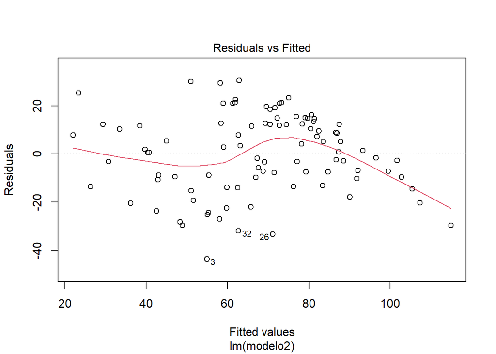

```r
plot(hip2, 1)
```

2. Homocedasticidad: se asume que el error del modelo de regresión no afecta la varianza o dispersión de la estimación.

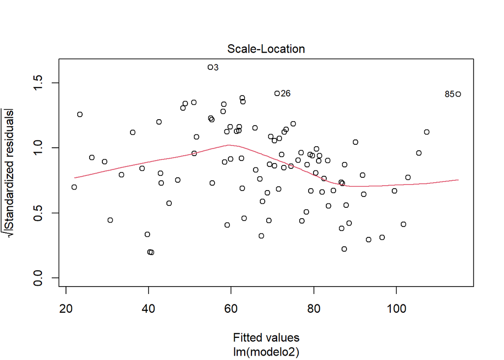

```r
plot(hip2, 3)
```

3. Test Breusch-Pagan:

```r
library(lmtest)
bptest(hip2)
```

```
##
##  studentized Breusch-Pagan test
##
## data:  hip2
## BP = 3.4185, df = 3, p-value = 0.3315
```

El p-value de esta prueba es mayor a 0.05, por lo que no se rechaza que el modelo muestra una homocedasticidad entre las variables.

4. Normalidad de residuos

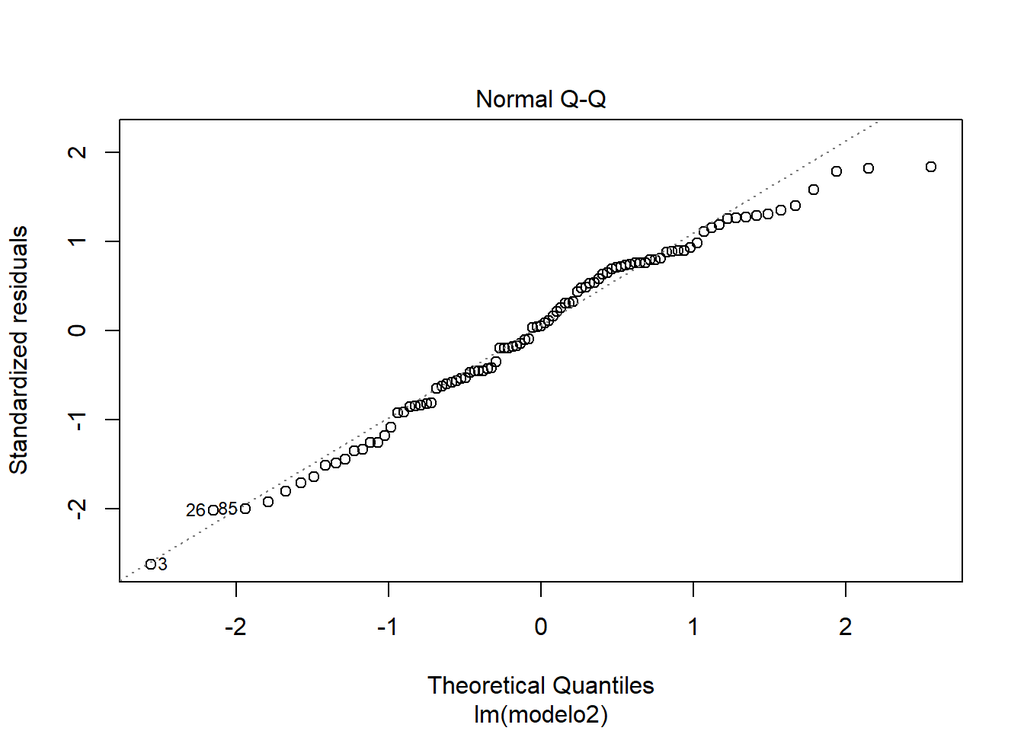

```r
plot(hip2, 2)
```

5. Test de Shapiro-Wilk con residuales

```r
shapiro.test(hip2$residuals)
```

```
##
##  Shapiro-Wilk normality test
##
## data:  hip2$residuals
## W = 0.97819, p-value = 0.1138
```

El p-value en la muestra de shapiro indica que es 0.1138, es decir mayor a 0.05, por lo que significa que no se rechaza que en el modelo existe una normalidad de residuos.

6. Test de no multicolinedad:

```r
library(DescTools)
VIF(hip2)
```

```
##    PBIPC  Pobreza gastoedu
## 1.392037 1.252927 1.148293
```

Observamos que las variables independientes no son mayores a 5 entre si, por lo que no existe una correlación entre ellos, es decir, no hay problema alguno entre ellos.

7. Valores influyentes:

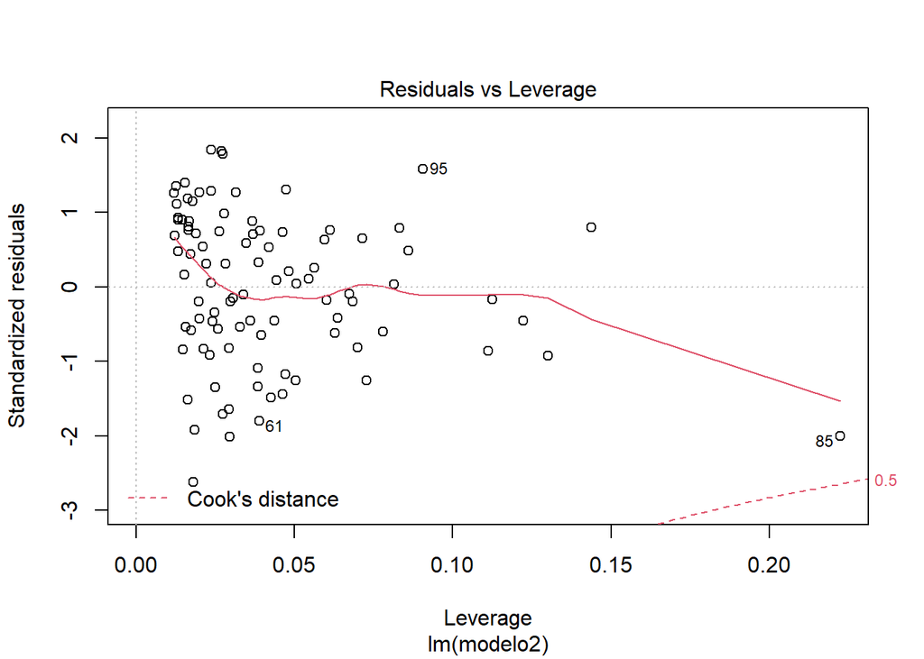

```r
plot(hip2, 5)
```

8. índice de Cook y valores predecidos: Existencia de casos influyentes

```r
checkHip2=as.data.frame(influence.measures(hip2)$is.inf)
head(checkHip2)
```

```
##   dfb.1_ dfb.PBIP dfb.Pbrz dfb.gstd dffit cov.r cook.d   hat
## 1  FALSE    FALSE    FALSE    FALSE FALSE FALSE  FALSE FALSE
## 2  FALSE    FALSE    FALSE    FALSE FALSE FALSE  FALSE FALSE
## 3  FALSE    FALSE    FALSE    FALSE FALSE  TRUE  FALSE FALSE
## 4  FALSE    FALSE    FALSE    FALSE FALSE FALSE  FALSE FALSE
## 5  FALSE    FALSE    FALSE    FALSE FALSE FALSE  FALSE FALSE
## 6  FALSE    FALSE    FALSE    FALSE FALSE FALSE  FALSE FALSE
```

```r
checkHip2[checkHip2$cook.d & checkHip2$hat,]
```

```
## [1] dfb.1_   dfb.PBIP dfb.Pbrz dfb.gstd dffit    cov.r    cook.d   hat
## <0 rows> (or 0-length row.names)
```

Ahora, utilizamos otra base de datos para clusterizar información relevante y poder analizarlo de manera factorial

```r
data2="https://github.com/fernandaVR1/Est-2/raw/main/ENTREGABLE%201.xlsx"
data2=import(data2)
str(data2)
```

```
## 'data.frame':    189 obs. of  5 variables:
##  $ paises: chr  "Afghanistan" "Albania" "Algeria" "Andorra" ...
##  $ EVN   : num  64.8 78.6 76.9 81.9 61.1 77 76.7 75.1 83.4 81.5 ...
##  $ GPBI  : num  11.8 NA 6.4 10.3 2.8 4.5 9.1 10.4 9.2 10.4 ...
##  $ TMI   : num  47.9 7.8 20.1 2.7 51.6 5 8.8 11 3.1 2.9 ...
##  $ HR    : num  6.7 2.3 1.4 0 NA NA 5.3 1.7 0.9 1 ...
```

Vemos los nombres y ajustamos para una unión correcta

```r
list(names(data1), names(data2))
```

```
## [[1]]
## [1] "Pais"      "Matricula" "PBIPC"     "gastoedu"  "Pobreza"
##
## [[2]]
## [1] "paises" "EVN"    "GPBI"   "TMI"    "HR"
```

Se realiza el MERGE más sencillo

```r
allData=merge(data1,data2,by.x='Pais', by.y='paises')
str(allData)
```

```
## 'data.frame':    95 obs. of  9 variables:
##  $ Pais     : chr  "Afghanistan" "Albania" "Angola" "Argentina" ...
##  $ Matricula: num  50.1 86.6 11.3 90.8 87.7 ...
##  $ PBIPC    : num  552 5224 3437 11688 4212 ...
##  $ gastoedu : num  4.06 2.47 3.42 5.46 2.71 5.5 1.99 4.79 6.55 7.38 ...
##  $ Pobreza  : num  54.5 14.3 36.6 25.7 32 3 24.3 5.7 15.1 41 ...
##  $ EVN      : num  64.8 78.6 61.1 76.7 75.1 81.5 72.6 74.8 81.6 74.6 ...
##  $ GPBI     : num  11.8 NA 2.8 9.1 10.4 10.4 2.3 5.9 10.3 5.6 ...
##  $ TMI      : num  47.9 7.8 51.6 8.8 11 2.9 25.1 2.6 2.9 11.2 ...
##  $ HR       : num  6.7 2.3 NA 5.3 1.7 1 2.4 2.4 1.7 37.8 ...
```

Observamos la estructura (descripción estadísitica)

```r
summary(allData)
```

```
##      Pais             Matricula         PBIPC          gastoedu
##  Length:95          Min.   :11.29   Min.   :  294   Min.   :1.110
##  Class :character   1st Qu.:43.78   1st Qu.: 1545   1st Qu.:3.595
##  Mode  :character   Median :77.47   Median : 4901   Median :4.560
##                     Mean   :67.81   Mean   :11824   Mean   :4.427
##                     3rd Qu.:90.06   3rd Qu.:15059   3rd Qu.:5.255
##                     Max.   :99.84   Max.   :82709   Max.   :7.670
##
##     Pobreza           EVN             GPBI             TMI
##  Min.   : 2.60   Min.   :53.30   Min.   : 2.300   Min.   : 1.70
##  1st Qu.:15.05   1st Qu.:66.45   1st Qu.: 4.750   1st Qu.: 6.10
##  Median :23.40   Median :74.30   Median : 6.600   Median :13.10
##  Mean   :27.93   Mean   :72.14   Mean   : 6.791   Mean   :22.65
##  3rd Qu.:36.80   3rd Qu.:77.50   3rd Qu.: 8.375   3rd Qu.:35.10
##  Max.   :72.30   Max.   :83.80   Max.   :17.100   Max.   :84.50
##                                  NA's   :1
##        HR
##  Min.   : 0.300
##  1st Qu.: 1.200
##  Median : 2.400
##  Mean   : 7.821
##  3rd Qu.: 7.100
##  Max.   :52.000
##  NA's   :18
```

Observamos la distribución (posible transformación)

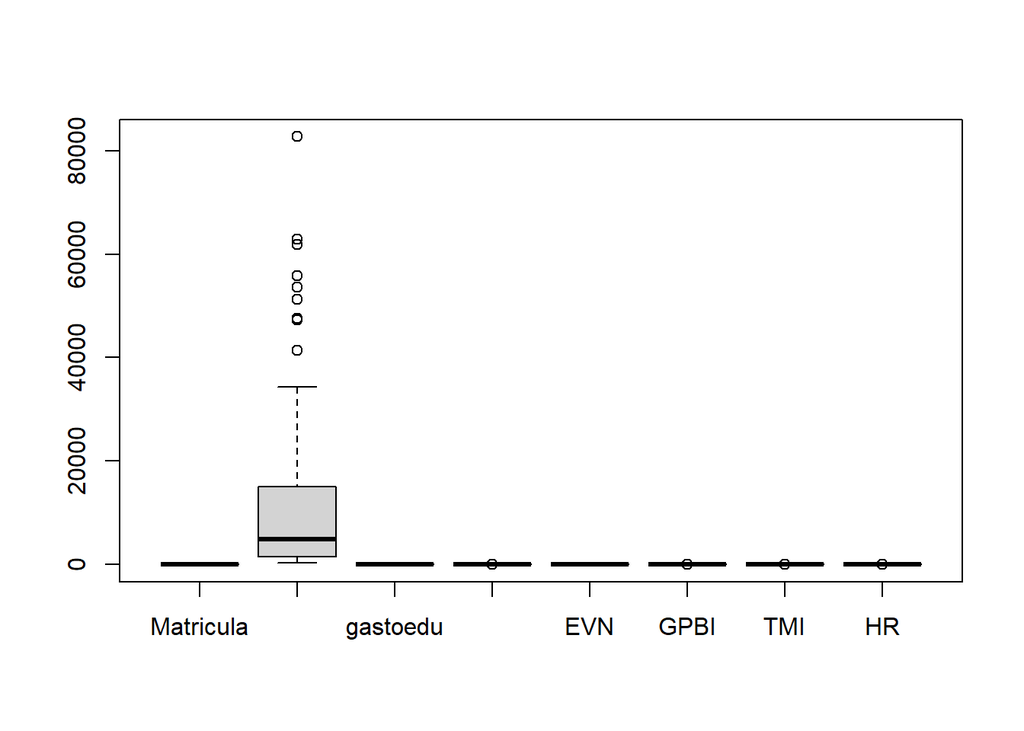

```r
boxplot(allData[,-1])
```

Transformación de las variables

```r
library(BBmisc)
```

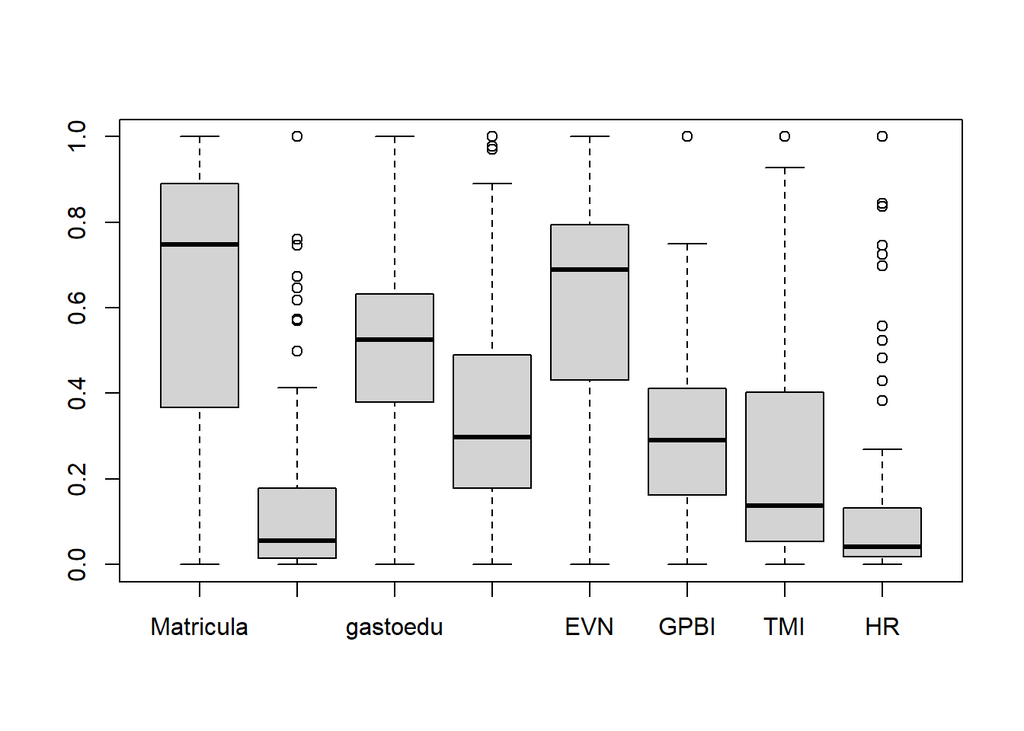

```r
boxplot(normalize(allData[,-1],method='range',range=c(0,1)))
```

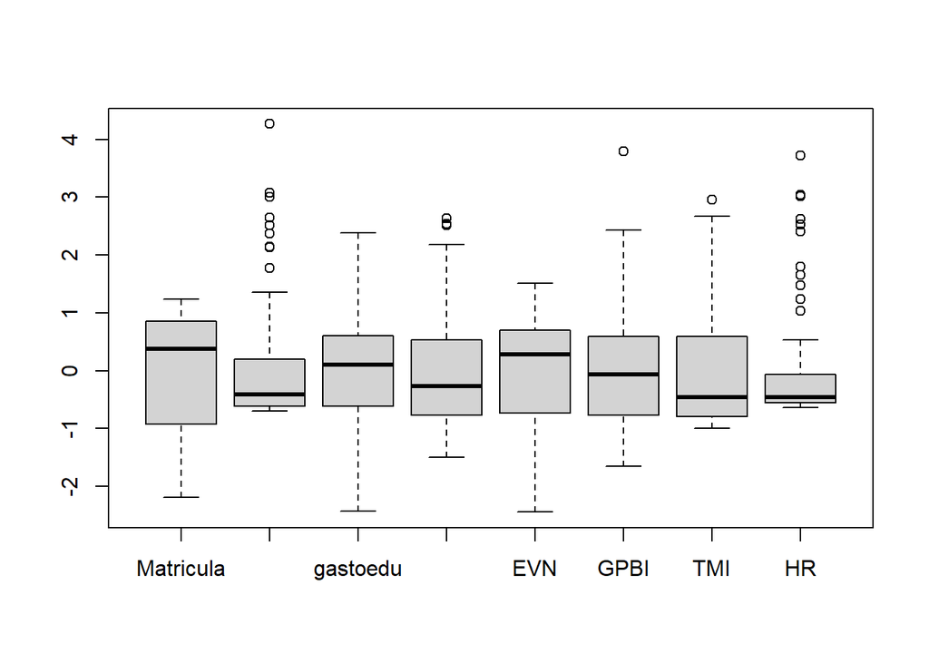

```r
boxplot(normalize(allData[,-1],method='standardize'))
```

Se opta por la segunda opción del boxplot

```r
allData[,-1]=normalize(allData[,-1],method='standardize')
allData=allData[complete.cases(allData),]

summary(allData)
```

```
##      Pais             Matricula           PBIPC            gastoedu
##  Length:76          Min.   :-2.1315   Min.   :-0.6939   Min.   :-2.4327
##  Class :character   1st Qu.:-0.2088   1st Qu.:-0.5405   1st Qu.:-0.4544
##  Mode  :character   Median : 0.6100   Median :-0.2856   Median : 0.1598
##                     Mean   : 0.2768   Mean   : 0.1523   Mean   : 0.1207
##                     3rd Qu.: 0.9415   3rd Qu.: 0.2876   3rd Qu.: 0.7153
##                     Max.   : 1.2390   Max.   : 4.2663   Max.   : 2.3782
##     Pobreza             EVN                GPBI               TMI
##  Min.   :-1.5038   Min.   :-2.44453   Min.   :-1.65037   Min.   :-1.00248
##  1st Qu.:-0.8151   1st Qu.:-0.07344   1st Qu.:-0.60315   1st Qu.:-0.89480
##  Median :-0.3580   Median : 0.37742   Median : 0.03987   Median :-0.55500
##  Mean   :-0.2085   Mean   : 0.23999   Mean   : 0.12545   Mean   :-0.23780
##  3rd Qu.: 0.1600   3rd Qu.: 0.83153   3rd Qu.: 0.74720   3rd Qu.: 0.07795
##  Max.   : 2.5096   Max.   : 1.51269   Max.   : 3.78780   Max.   : 2.96029
##        HR
##  Min.   :-0.63363
##  1st Qu.:-0.55780
##  Median :-0.45249
##  Mean   : 0.00612
##  3rd Qu.:-0.05862
##  Max.   : 3.72211
```

```r
cor(allData[,-1])
```

```
##            Matricula      PBIPC   gastoedu     Pobreza        EVN        GPBI
## Matricula  1.0000000  0.5168260  0.2226708 -0.71069236  0.7941280  0.24704281
## PBIPC      0.5168260  1.0000000  0.3464815 -0.40042823  0.6377828  0.62720412
## gastoedu   0.2226708  0.3464815  1.0000000 -0.11324976  0.1752585  0.43028146
## Pobreza   -0.7106924 -0.4004282 -0.1132498  1.00000000 -0.6510846 -0.04620096
## EVN        0.7941280  0.6377828  0.1752585 -0.65108463  1.0000000  0.31074145
## GPBI       0.2470428  0.6272041  0.4302815 -0.04620096  0.3107415  1.00000000
## TMI       -0.8502912 -0.4929428 -0.1765293  0.70637857 -0.9234718 -0.20682062
## HR        -0.2570411 -0.2637991  0.1792278  0.27660271 -0.2162627 -0.02173099
##                  TMI          HR
## Matricula -0.8502912 -0.25704107
## PBIPC     -0.4929428 -0.26379908
## gastoedu  -0.1765293  0.17922776
## Pobreza    0.7063786  0.27660271
## EVN       -0.9234718 -0.21626272
## GPBI      -0.2068206 -0.02173099
## TMI        1.0000000  0.13892359
## HR         0.1389236  1.00000000
```

Ahora, hacemos el proceso de clusterización

```r
dataClus=allData[,-1]
row.names(dataClus)=allData$Pais
```

Formamos la base “dataClus”

```r
library(cluster)
g.dist = daisy(dataClus, metric="gower")
```

Proponemos la cantidad de clusters

```r
set.seed(123)
pam.resultado=pam(g.dist,8,cluster.only = F)

dataClus$pam=pam.resultado$cluster
```

Resultado preliminar del cluster

```r
aggregate(.~ pam, data=dataClus,mean)
```

```
##   pam    Matricula       PBIPC    gastoedu     Pobreza        EVN        GPBI
## 1   1 -1.131626263 -0.65237635 -0.27475703  0.92887569 -1.1551899 -0.39646779
## 2   2  0.843727839  0.01492857  0.05426526 -0.74182037  0.5994841 -0.07460128
## 3   3 -0.001492554 -0.28746809 -0.70193598  0.08968002  0.3268204 -0.01891944
## 4   4  0.953587741  2.18472750  0.77436290 -0.77127705  1.2931200  1.45594284
## 5   5 -0.107788668 -0.54324606 -0.08408487 -0.07967305 -0.3540156 -0.98437763
## 6   6  0.099193756 -0.34726790  0.81244091 -0.05963565  0.2087526  0.12254637
## 7   7 -2.131477109 -0.68270331 -2.43265243  2.02276888 -2.4445292 -0.36431647
## 8   8 -1.015706433 -0.65794527  1.75846813  2.11776096 -2.2888354  1.58313487
##          TMI          HR
## 1  1.3264855 -0.42826708
## 2 -0.7641047 -0.37180327
## 3 -0.3032535  0.06817698
## 4 -0.9181757 -0.55067284
## 5  0.2029814 -0.34085754
## 6 -0.3958619  2.40359139
## 7  2.9602925  1.03452630
## 8  2.3668335  1.24936421
```

Recodificación del cluster

```r
original=aggregate(.~ pam, data=dataClus,mean)
original[order(original$PBIPC),]
```

```
##   pam    Matricula       PBIPC    gastoedu     Pobreza        EVN        GPBI
## 7   7 -2.131477109 -0.68270331 -2.43265243  2.02276888 -2.4445292 -0.36431647
## 8   8 -1.015706433 -0.65794527  1.75846813  2.11776096 -2.2888354  1.58313487
## 1   1 -1.131626263 -0.65237635 -0.27475703  0.92887569 -1.1551899 -0.39646779
## 5   5 -0.107788668 -0.54324606 -0.08408487 -0.07967305 -0.3540156 -0.98437763
## 6   6  0.099193756 -0.34726790  0.81244091 -0.05963565  0.2087526  0.12254637
## 3   3 -0.001492554 -0.28746809 -0.70193598  0.08968002  0.3268204 -0.01891944
## 2   2  0.843727839  0.01492857  0.05426526 -0.74182037  0.5994841 -0.07460128
## 4   4  0.953587741  2.18472750  0.77436290 -0.77127705  1.2931200  1.45594284
##          TMI          HR
## 7  2.9602925  1.03452630
## 8  2.3668335  1.24936421
## 1  1.3264855 -0.42826708
## 5  0.2029814 -0.34085754
## 6 -0.3958619  2.40359139
## 3 -0.3032535  0.06817698
## 2 -0.7641047 -0.37180327
## 4 -0.9181757 -0.55067284
```

```r
dataClus$pam=dplyr::recode(dataClus$pam, `7` = 1, `8`=2,`1`=3, `5` = 4, `6`=5,`3`=6, `2` = 7, `4`=8)
```

Proposición de cantidad de clusters:

```r
library(factoextra)
```

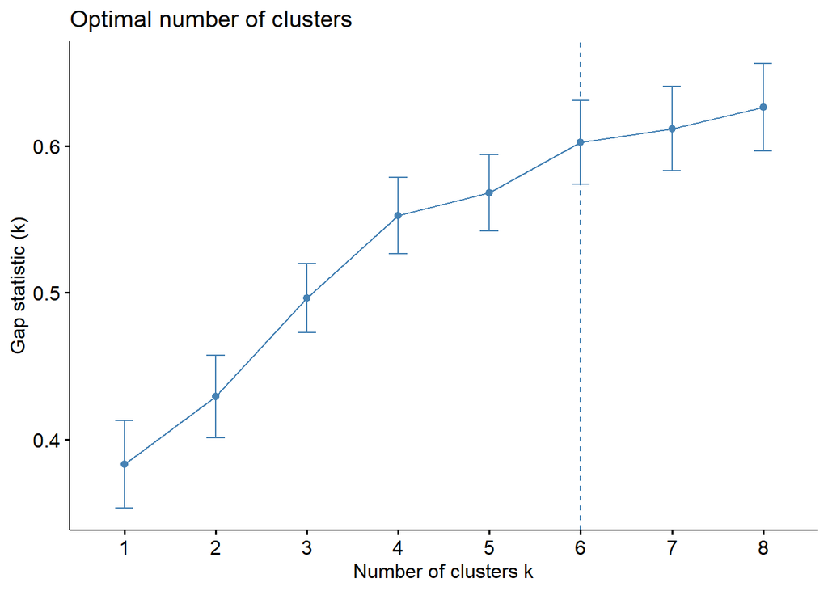

```r
fviz_nbclust(dataClus, pam,diss=g.dist,method = "gap_stat",k.max = 8,verbose = F)
```

Estrategia jerárquica

1. Estrategia aglomerativa

```r
set.seed(123)
library(factoextra)

res.agnes<- hcut(g.dist, k = 8,hc_func='agnes',hc_method = "ward.D")

dataClus$agnes=res.agnes$cluster
```

Resultado preliminar del cluster

```r
aggregate(.~ agnes, data=dataClus,mean)
```

```
##   agnes  Matricula      PBIPC   gastoedu    Pobreza         EVN        GPBI
## 1     1 -1.1218671 -0.6321965 -0.4261947  0.9956670 -0.93689424 -0.36064203
## 2     2  0.9366021  0.4350196  0.2926760 -0.4199377  0.92883641  0.37516388
## 3     3  0.7837124 -0.2763940 -0.3543260 -0.8970502  0.39601764 -0.33002173
## 4     4  0.9194825  2.5223571  1.0331806 -0.9207982  1.25709082  1.66029804
## 5     5 -0.1124957 -0.4352904 -0.4098165 -0.2743573 -0.02370688 -0.57865860
## 6     6  0.1829346 -0.2920727  0.7567060  0.0617761  0.15425977 -0.03729162
## 7     7 -2.1314771 -0.6827033 -2.4326524  2.0227689 -2.44452916 -0.36431647
## 8     8 -1.0157064 -0.6579453  1.7584681  2.1177610 -2.28883536  1.58313487
##            TMI         HR      pam
## 1  1.079410279 -0.2629261 3.400000
## 2 -0.860099965 -0.3577076 7.187500
## 3 -0.671612911 -0.4173848 6.866667
## 4 -0.907720266 -0.5350542 8.000000
## 5 -0.008996765 -0.2720532 5.000000
## 6 -0.353984707  2.0160407 5.000000
## 7  2.960292514  1.0345263 1.000000
## 8  2.366833489  1.2493642 2.000000
```

Recodificación del cluster

```r
original=aggregate(.~ agnes, data=dataClus,mean)
original[order(original$PBIPC),]
```

```
##   agnes  Matricula      PBIPC   gastoedu    Pobreza         EVN        GPBI
## 7     7 -2.1314771 -0.6827033 -2.4326524  2.0227689 -2.44452916 -0.36431647
## 8     8 -1.0157064 -0.6579453  1.7584681  2.1177610 -2.28883536  1.58313487
## 1     1 -1.1218671 -0.6321965 -0.4261947  0.9956670 -0.93689424 -0.36064203
## 5     5 -0.1124957 -0.4352904 -0.4098165 -0.2743573 -0.02370688 -0.57865860
## 6     6  0.1829346 -0.2920727  0.7567060  0.0617761  0.15425977 -0.03729162
## 3     3  0.7837124 -0.2763940 -0.3543260 -0.8970502  0.39601764 -0.33002173
## 2     2  0.9366021  0.4350196  0.2926760 -0.4199377  0.92883641  0.37516388
## 4     4  0.9194825  2.5223571  1.0331806 -0.9207982  1.25709082  1.66029804
##            TMI         HR      pam
## 7  2.960292514  1.0345263 1.000000
## 8  2.366833489  1.2493642 2.000000
## 1  1.079410279 -0.2629261 3.400000
## 5 -0.008996765 -0.2720532 5.000000
## 6 -0.353984707  2.0160407 5.000000
## 3 -0.671612911 -0.4173848 6.866667
## 2 -0.860099965 -0.3577076 7.187500
## 4 -0.907720266 -0.5350542 8.000000
```

```r
dataClus$agnes=dplyr::recode(dataClus$agnes, `7` = 1, `8`=2,`1`=3, `5` = 4, `6`=5,`3`=6, `2` = 7, `4`=8)
```

Visualización de diagrama

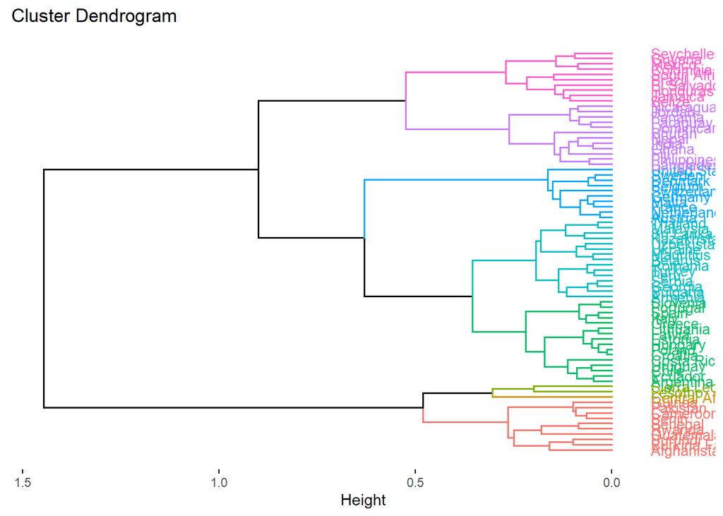

```r
fviz_dend(res.agnes, cex = 0.7, horiz = T)
```

Comparando

```r
table(dataClus$pam,dataClus$agnes,dnn = c('Particion','Aglomeracion'))
```

```
##          Aglomeracion
## Particion  1  2  3  4  5  6  7  8
##         1  1  0  0  0  0  0  0  0
##         2  0  2  0  0  0  0  0  0
##         3  0  0  8  0  0  0  0  0
##         4  0  0  1  6  1  0  0  0
##         5  0  0  0  0  8  0  0  0
##         6  0  0  1  6  1  2  0  0
##         7  0  0  0  0  0 13 13  0
##         8  0  0  0  0  0  0  3 10
```

Proposición de clusters:

PAM

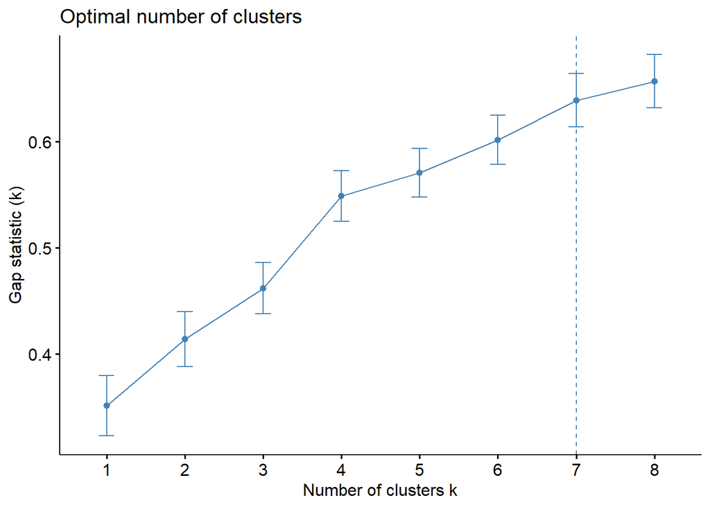

```r
library(factoextra)
fviz_nbclust(dataClus, pam,diss=g.dist,method = "gap_stat",k.max = 8,verbose = F)
```

AGNES

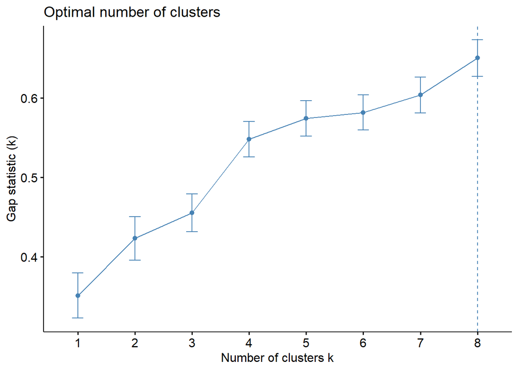

```r
fviz_nbclust(dataClus, hcut,diss=g.dist,method = "gap_stat",k.max = 8,verbose = F,hc_func = "agnes")
```

2. Estrategia divisa

```r
set.seed(123)
res.diana <- hcut(g.dist, k = 8,hc_func='diana')
dataClus$diana=res.diana$cluster
```

Resultado preliminar

```r
aggregate(.~ diana, data=dataClus,mean)
```

```
##   diana    Matricula       PBIPC    gastoedu    Pobreza         EVN
## 1     1 -1.069792682 -0.64632492 -0.34845915  0.7872781 -1.06923397
## 2     2  0.821407664 -0.04970483  0.02460873 -0.7118581  0.56647763
## 3     3  0.962509434  2.08964141  0.73858165 -0.7756809  1.28563469
## 4     4  0.007301595 -0.36822607 -0.27151334 -0.1520018  0.04856764
## 5     5  0.036449618 -0.37191628  0.73858165  0.1331050  0.16890240
## 6     6 -2.131477109 -0.68270331 -2.43265243  2.0227689 -2.44452916
## 7     7 -0.929818399 -0.43784568 -1.09794737  1.8624697  0.28011226
## 8     8 -1.015706433 -0.65794527  1.75846813  2.1177610 -2.28883536
##           GPBI         TMI         HR      pam    agnes
## 1 -0.452502946  1.14067057 -0.4347965 3.200000 3.100000
## 2 -0.028367990 -0.73019534 -0.2824842 6.857143 6.392857
## 3  1.388914660 -0.92419764 -0.5553946 7.928571 7.714286
## 4 -0.539558826 -0.08210537 -0.1423836 5.076923 4.153846
## 5 -0.002122015 -0.38509345  2.5113112 5.000000 5.000000
## 6 -0.364316470  2.96029251  1.0345263 1.000000 1.000000
## 7 -0.364316470 -0.02614645  1.2367267 6.000000 3.000000
## 8  1.583134875  2.36683349  1.2493642 2.000000 2.000000
```

Visualización

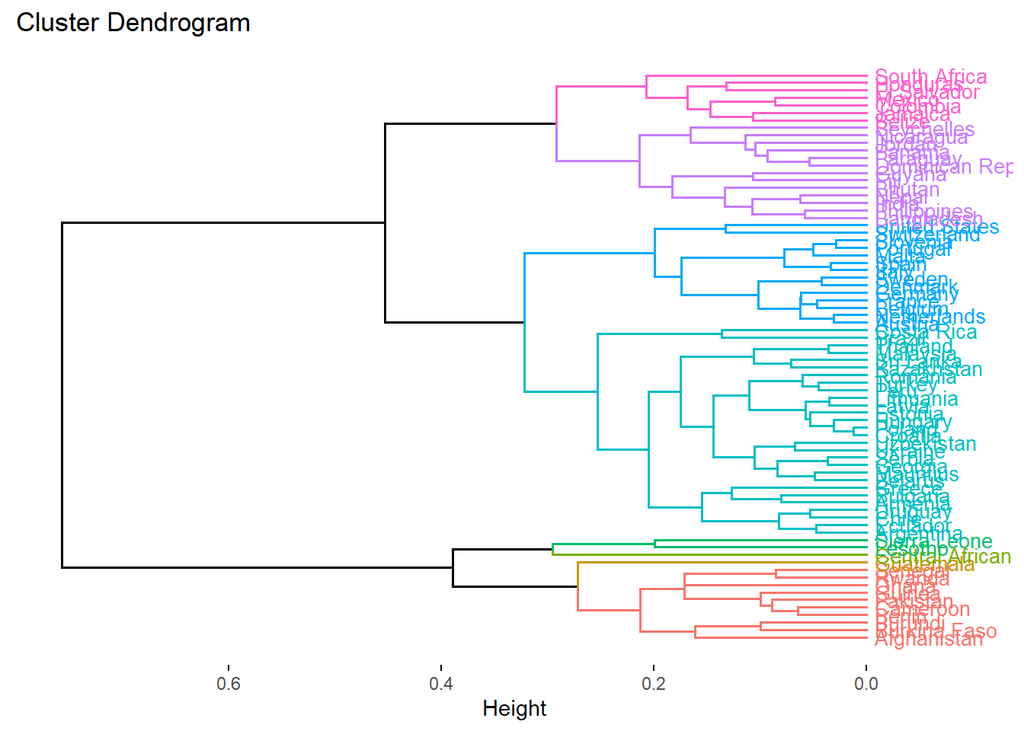

```r
fviz_dend(res.diana, cex = 0.7, horiz = T)
```

Comparando

```r
table(dataClus$diana,dataClus$agnes,dnn = c('Division','Aglomeracion'))
```

```
##         Aglomeracion
## Division  1  2  3  4  5  6  7  8
##        1  0  0  9  1  0  0  0  0
##        2  0  0  0  0  1 15 12  0
##        3  0  0  0  0  0  0  4 10
##        4  0  0  0 11  2  0  0  0
##        5  0  0  0  0  7  0  0  0
##        6  1  0  0  0  0  0  0  0
##        7  0  0  1  0  0  0  0  0
##        8  0  2  0  0  0  0  0  0
```

DIANA

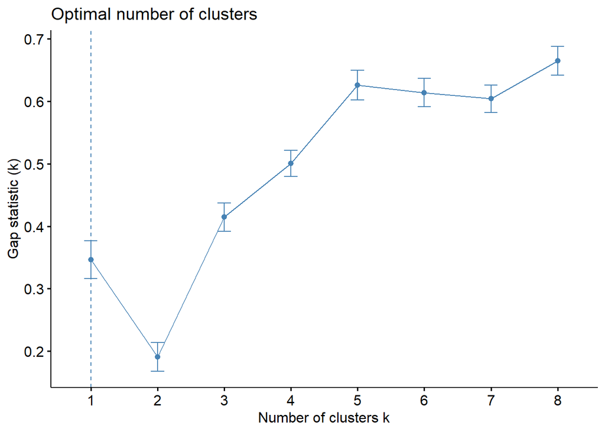

```r
fviz_nbclust(dataClus, hcut,diss=g.dist,method = "gap_stat",k.max = 8,verbose = F,hc_func = "diana")
```

Ahora observamos:

3)Estrategias de densidad

```r
proyeccion = cmdscale(g.dist, k=8,add = T)
```

Utilizamos la estrategia de escalamiento multidimensional

```r
dataClus$dim1 <- proyeccion$points[,1]
dataClus$dim2 <- proyeccion$points[,2]
```

Observación del mapa

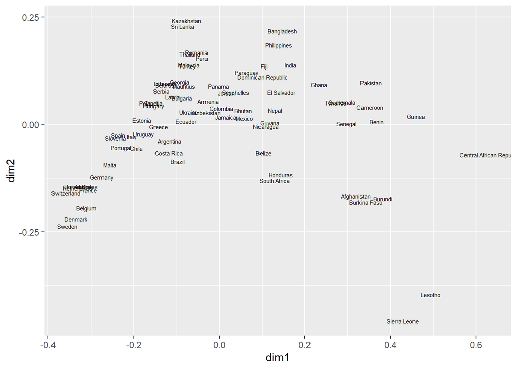

```r
base= ggplot(dataClus,aes(x=dim1, y=dim2,label=row.names(dataClus)))
base + geom_text(size=2)
```

Gráfico PAM

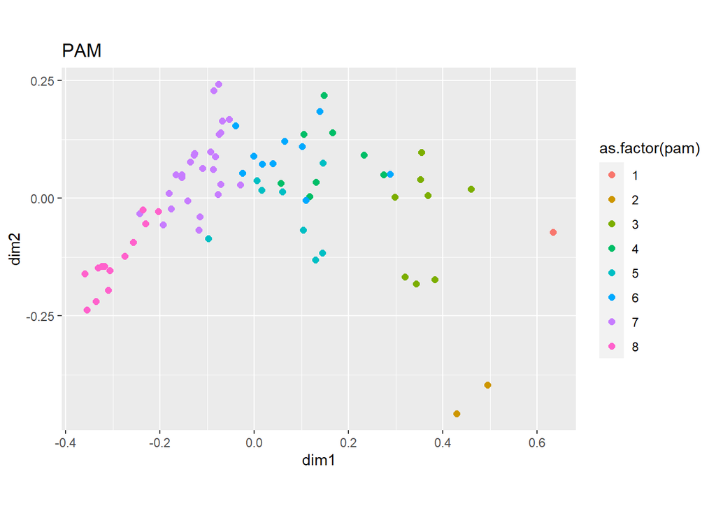

```r
base= ggplot(dataClus,aes(x=dim1, y=dim2)) +  coord_fixed()
base + geom_point(size=2, aes(color=as.factor(pam)))  + labs(title = "PAM")
```

Gráfico AGNES

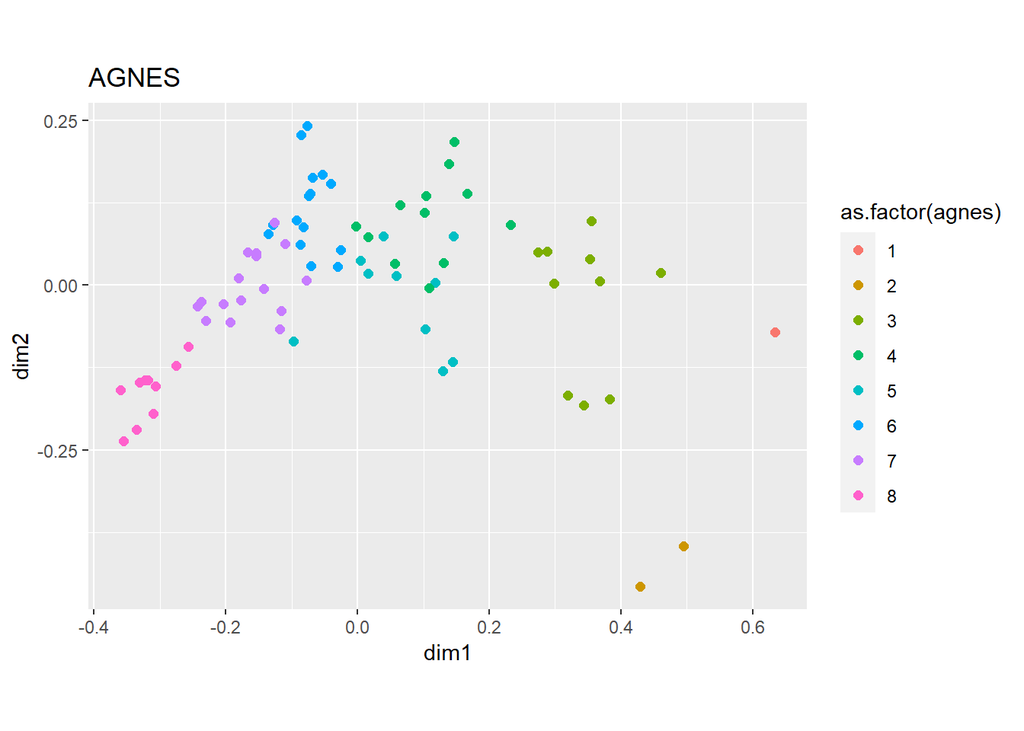

```r
base + geom_point(size=2, aes(color=as.factor(agnes))) + labs(title = "AGNES")
```

Gráfico DIANA

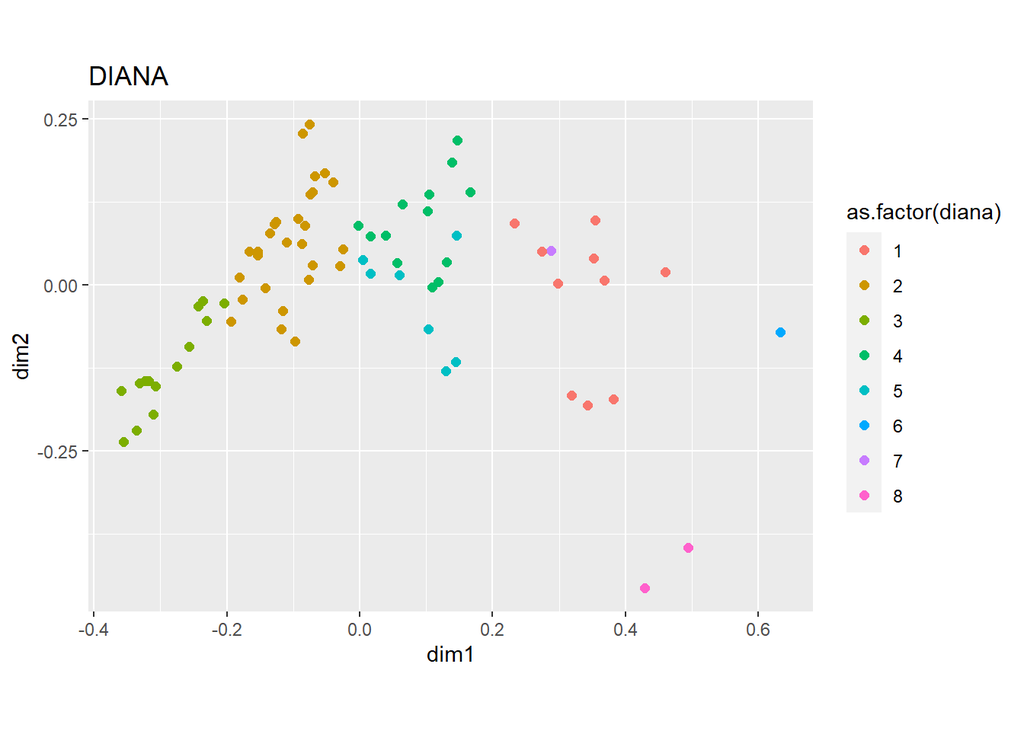

```r
base + geom_point(size=2, aes(color=as.factor(diana))) + labs(title = "DIANA")
```

Ahora calculamos el epsilon mediante dbscan

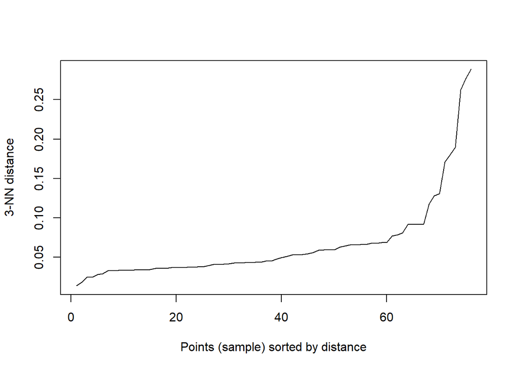

```r
g.dist.cmd = daisy(dataClus[,c('dim1','dim2')], metric = 'euclidean')
library(dbscan)
kNNdistplot(g.dist.cmd, k=3)
```

Obteniendo clusters:

```r
library(fpc)
db.cmd = fpc::dbscan(g.dist.cmd, eps=0.065, MinPts=3,method = 'dist')
db.cmd
```

```
## dbscan Pts=76 MinPts=3 eps=0.065
##        0 1  2 3 4
## border 6 0  2 2 1
## seed   0 3 58 1 3
## total  6 3 60 3 4
```

Ahora lo colocamos en otra columna

```r
dataClus$db=as.factor(db.cmd$cluster)
```

Graficando:

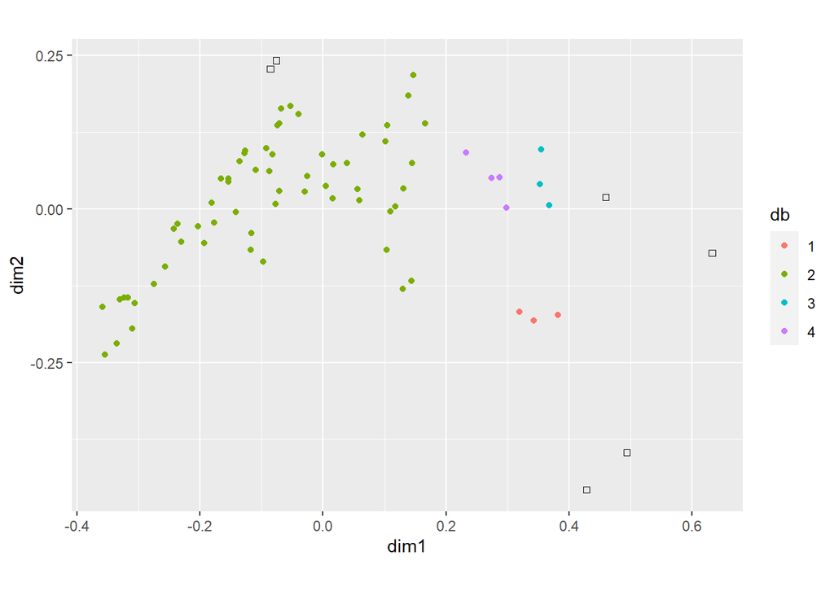

```r
library(ggrepel)
base= ggplot(dataClus[dataClus$db!=0,],aes(x=dim1, y=dim2)) + coord_fixed()

dbplot= base + geom_point(aes(color=db))

dbplot + geom_point(data=dataClus[dataClus$db==0,],
                    shape=0)
```

Evaluando los resultados

```r
set.seed(123)
grupos=4
res.pam=pam(g.dist,k = grupos,cluster.only = F)
dataClus$pam=res.pam$cluster

###agnes
res.agnes<- hcut(g.dist, k =grupos,hc_func='agnes',hc_method = "ward.D")
dataClus$agnes=res.agnes$cluster

### diana
res.diana <- hcut(g.dist, k = grupos,hc_func='diana')
dataClus$diana=res.diana$cluster
```

Evaluamos resultados

```
##   cluster size ave.sil.width
## 1       1   12          0.27
## 2       2   27          0.32
## 3       3   24          0.06
## 4       4   13          0.40
```

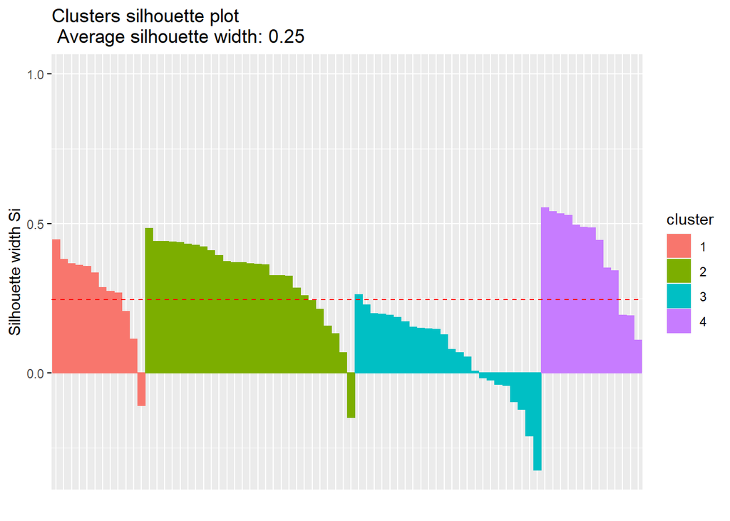

```r
fviz_silhouette(res.pam)
```

```
##   cluster size ave.sil.width
## 1       1   13          0.25
## 2       2   31          0.32
## 3       3   10          0.50
## 4       4   22          0.10
```

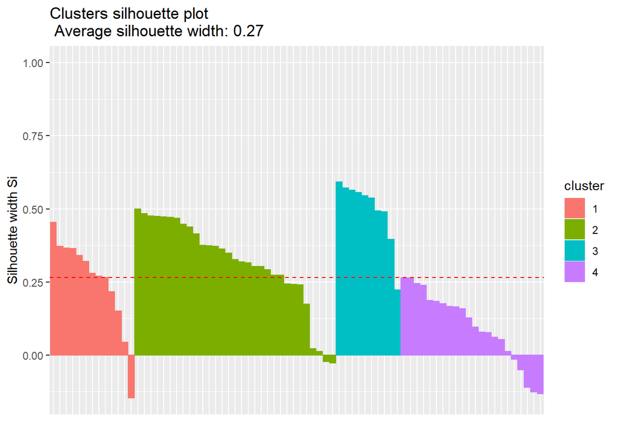

```r
fviz_silhouette(res.agnes)
```

```
##   cluster size ave.sil.width
## 1       1   11          0.32
## 2       2   42          0.34
## 3       3   20          0.21
## 4       4    3          0.13
```

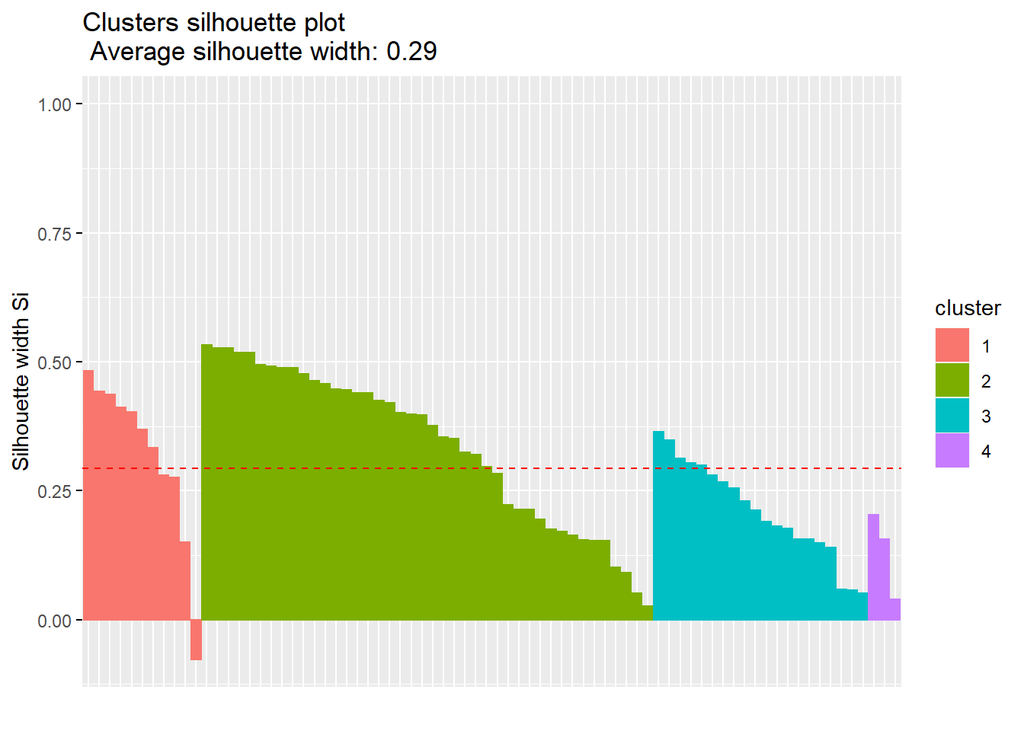

```r
fviz_silhouette(res.diana)
```

```r
library(magrittr)
```

```r
silPAM=data.frame(res.pam$silinfo$widths)
silPAM$country=row.names(silPAM)
poorPAM=silPAM[silPAM$sil_width<0,'country']%>%sort()

silAGNES=data.frame(res.agnes$silinfo$widths)
silAGNES$country=row.names(silAGNES)
poorAGNES=silAGNES[silAGNES$sil_width<0,'country']%>%sort()

silDIANA=data.frame(res.diana$silinfo$widths)
silDIANA$country=row.names(silDIANA)
poorDIANA=silDIANA[silDIANA$sil_width<0,'country']%>%sort()

library("qpcR")
mal_Clus=as.data.frame(qpcR:::cbind.na(poorPAM, poorAGNES,poorDIANA))
mal_Clus
```

```
##       poorPAM  poorAGNES poorDIANA
## 1     Armenia     Brazil Guatemala
## 2      Bhutan       Fiji      <NA>
## 3    Colombia  Guatemala      <NA>
## 4       Ghana      Italy      <NA>
## 5      Jordan     Jordan      <NA>
## 6      Panama     Panama      <NA>
## 7        Peru Seychelles      <NA>
## 8      Rwanda      Spain      <NA>
## 9  Seychelles       <NA>      <NA>
## 10   Slovenia       <NA>      <NA>
```

```r
intersect(poorPAM,poorAGNES)
```

```
## [1] "Jordan"     "Panama"     "Seychelles"
```

```r
setdiff(poorPAM,poorAGNES)
```

```
## [1] "Armenia"  "Bhutan"   "Colombia" "Ghana"    "Peru"     "Rwanda"   "Slovenia"
```

```r
setdiff(poorAGNES,poorPAM)
```

```
## [1] "Brazil"    "Fiji"      "Guatemala" "Italy"     "Spain"
```

Gráfico final

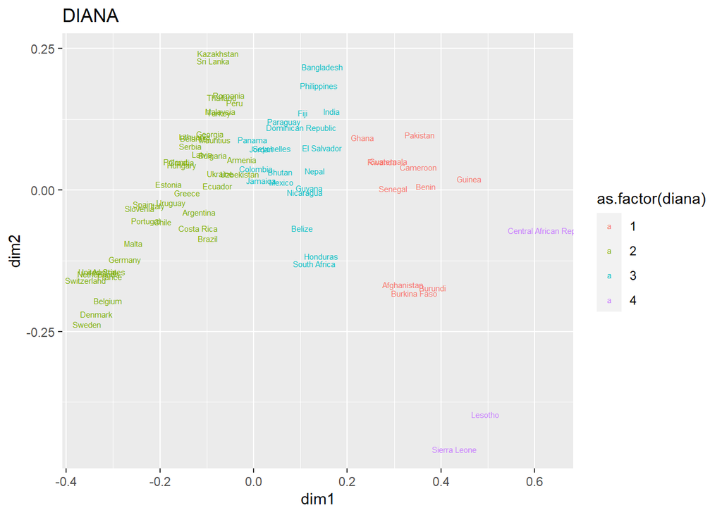

```r
proyeccion = cmdscale(g.dist, k=2,add = T)
base= ggplot(dataClus,aes(x=dim1, y=dim2,label=row.names(dataClus)))
base + geom_text(size=2, aes(color=as.factor(diana)))  + labs(title = "DIANA")
```

Ahora pasamos a realizar el análisis factorial (preparatorio)

```r
allData=na.omit(allData)

dontselect=c("Pais")
select=setdiff(names(allData),dontselect)
theData=allData[,select]
```

Calculamos la matriz de correlación

```r
library(polycor)
corMatrix=polycor::hetcor(allData)$correlations
```

```
## data contain one or more character variables
## the values of which are ordered alphabetically
```

Vemos un pequeño gráfico

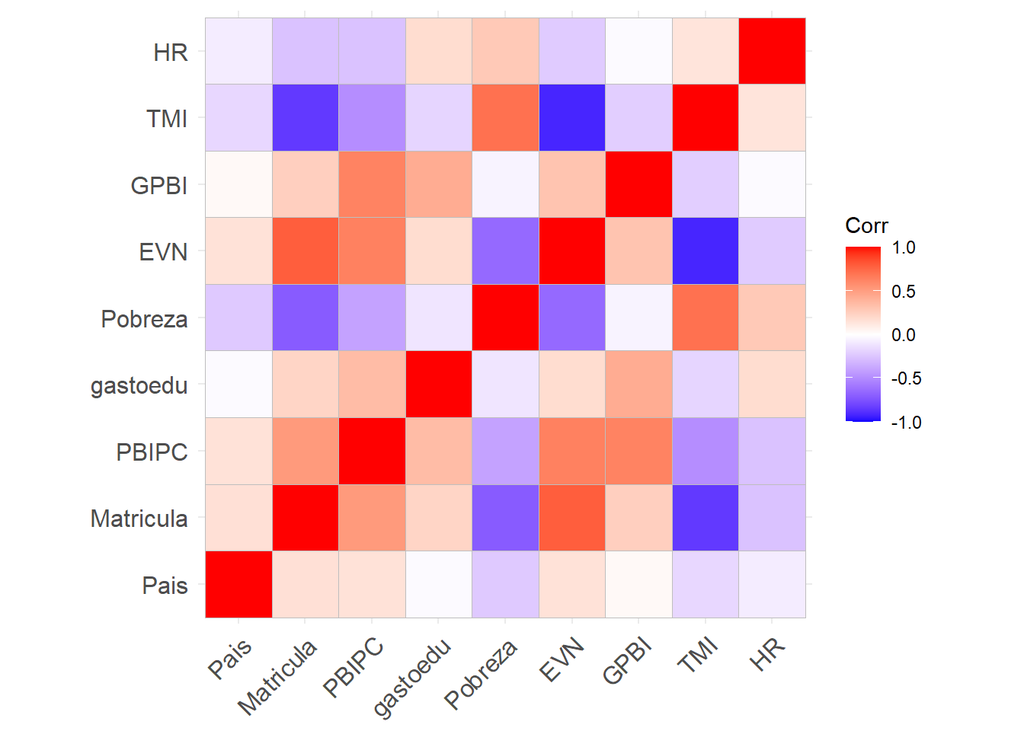

```r
library(ggcorrplot)

ggcorrplot(corMatrix)
```

Observamos si los datos nos permiten factorizar

```r
library(psych)
psych::KMO(corMatrix)
```

```
## Kaiser-Meyer-Olkin factor adequacy
## Call: psych::KMO(r = corMatrix)
## Overall MSA =  0.75
## MSA for each item =
##      Pais Matricula     PBIPC  gastoedu   Pobreza       EVN      GPBI       TMI
##      0.80      0.87      0.73      0.69      0.88      0.74      0.67      0.70
##        HR
##      0.55
```

Matriz identidad Hnula: La matriz de correlacion es una matriz identidad

```r
cortest.bartlett(corMatrix,n=nrow(allData))$p.value>0.05
```

```
## [1] FALSE
```

Matriz singular Hnula: La matriz de correlacion es una matriz singular.

```r
library(matrixcalc)

is.singular.matrix(corMatrix)
```

```
## [1] FALSE
```

Determinamos en cuantos factores o variables latentes podríamos redimensionar la data

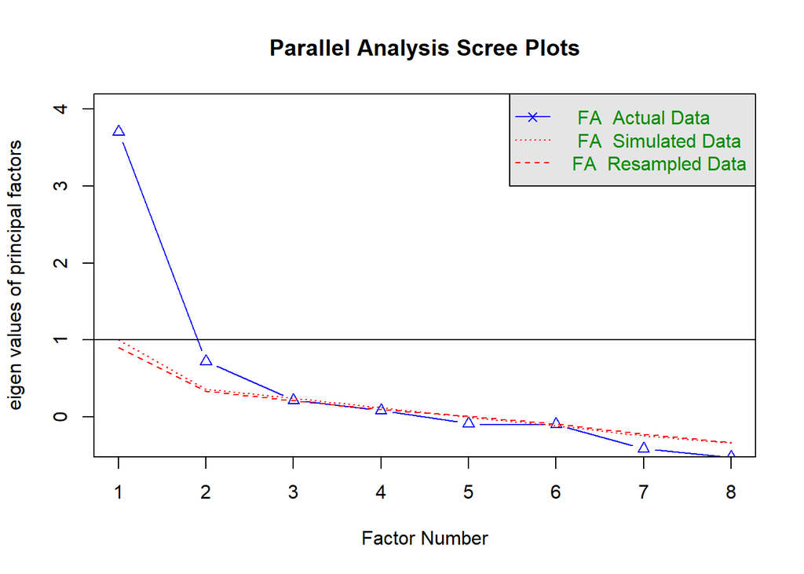

```
## Parallel analysis suggests that the number of factors =  2  and the number of components =  NA
```

```r
fa.parallel(theData,fm = 'ML', fa = 'fa',correct = T)
```

Redimensionamos el número de factores

```r
library(GPArotation)
resfa <- fa(theData,
            nfactors = 1,
            cor = 'mixed',
            rotate = "varimax",
            fm="minres")
print(resfa$loadings)
```

```
##
## Loadings:
##           MR1
## Matricula  0.886
## PBIPC      0.667
## gastoedu   0.260
## Pobreza   -0.710
## EVN        0.939
## GPBI       0.355
## TMI       -0.908
## HR        -0.245
##
##                  MR1
## SS loadings    3.692
## Proportion Var 0.461
```

Resultado mejorado

```r
print(resfa$loadings,cutoff = 0.5)
```

```
##
## Loadings:
##           MR1
## Matricula  0.886
## PBIPC      0.667
## gastoedu
## Pobreza   -0.710
## EVN        0.939
## GPBI
## TMI       -0.908
## HR
##
##                  MR1
## SS loadings    3.692
## Proportion Var 0.461
```

Resultado visual

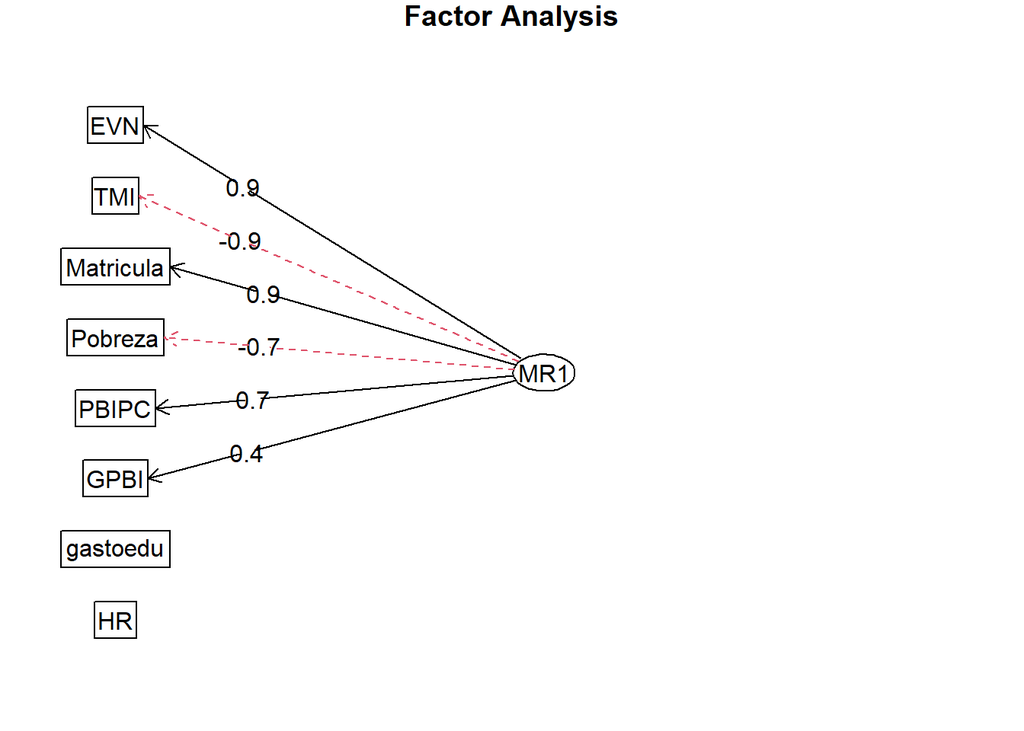

```r
fa.diagram(resfa)
```

¿Qué variables aportaron más a los factores?

```r
sort(resfa$communality)
```

```
##         HR   gastoedu       GPBI      PBIPC    Pobreza  Matricula        TMI
## 0.06007167 0.06760834 0.12617154 0.44482838 0.50363309 0.78443314 0.82415728
##        EVN
## 0.88081443
```

¿Qué variables contribuyen a más de un factor?

```r
sort(resfa$complexity)
```

```
##  gastoedu   Pobreza      GPBI Matricula       EVN       TMI     PBIPC        HR
##         1         1         1         1         1         1         1         1
```

¿Qué nombre le darías?

```r
as.data.frame(resfa$scores)%>%head()
```

```
##          MR1
## 1 -1.2786305
## 4  0.4953240
## 5  0.1987823
## 6  1.0997272
## 7 -0.4357966
## 8  0.4458489
```

Le daría nombre PBI

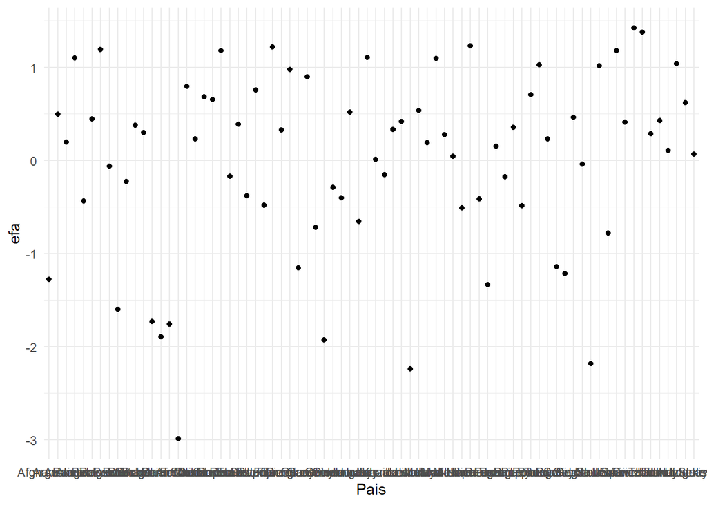

```r
allData$efa=resfa$scores

ggplot(data=allData,aes(x=Pais,y=efa)) + geom_point() + theme_minimal()
```

```r
library(BBmisc)
allData$efa_ok=normalize(allData$efa,
                       method = "range",
                       margin=2,
                       range = c(0, 10))
```

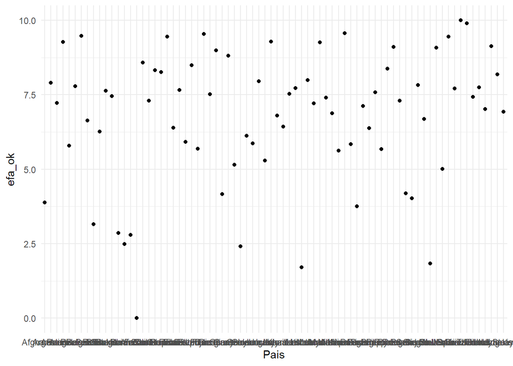

```r
ggplot(data=allData,aes(x=Pais,y=efa_ok)) + geom_point() + theme_minimal()
```

Ahora pasamos a realizar el análisis factorial (confirmatorio)

```r
model <- ' PBI  =~ EVN + TMI + Matricula + Pobreza + PBIPC + GPBI'
```

```r
theDataNorm=as.data.frame(scale(theData))

library(lavaan)
cfa_fit <- cfa(model, data=theDataNorm,
           std.lv=TRUE,
           missing="fiml")
```

Preparamos los tests:

```r
allParamCFA=parameterEstimates(cfa_fit,standardized = T)
allFitCFA=as.list(fitMeasures(cfa_fit))
```

Si cada indicador tiene una buena conexión con su latente (ver p valor)

```r
allParamCFA[allParamCFA$op=="=~",]
```

```
##   lhs op       rhs    est    se       z pvalue ci.lower ci.upper std.lv std.all
## 1 PBI =~       EVN  0.942 0.085  11.052  0.000    0.775    1.109  0.942   0.948
## 2 PBI =~       TMI -0.964 0.084 -11.521  0.000   -1.128   -0.800 -0.964  -0.970
## 3 PBI =~ Matricula  0.863 0.091   9.506  0.000    0.685    1.041  0.863   0.868
## 4 PBI =~   Pobreza -0.718 0.099  -7.241  0.000   -0.912   -0.524 -0.718  -0.723
## 5 PBI =~     PBIPC  0.570 0.108   5.289  0.000    0.359    0.782  0.570   0.574
## 6 PBI =~      GPBI  0.263 0.115   2.284  0.022    0.037    0.488  0.263   0.264
##   std.nox
## 1   0.948
## 2  -0.970
## 3   0.868
## 4  -0.723
## 5   0.574
## 6   0.264
```

El ChiSquare es NO significativo? (p_value debe ser mayor a 0.05 para que sea bueno)

```r
allFitCFA[c("chisq", "df", "pvalue")]
```

```
## $chisq
## [1] 72.19508
##
## $df
## [1] 9
##
## $pvalue
## [1] 5.643042e-12
```

El Índice Tucker Lewi es mayor a 0.9?

```r
allFitCFA$tli
```

```
## [1] 0.7267494
```

La Raíz del error cuadrático medio de aproximación es menor a 0.05?

```r
allFitCFA[c('rmsea.ci.lower','rmsea' ,'rmsea.ci.upper')]
```

```
## $rmsea.ci.lower
## [1] 0.2411322
##
## $rmsea
## [1] 0.303958
##
## $rmsea.ci.upper
## [1] 0.3709033
```

Ya sabemos que no hay buen augurio.

```r
scorescfa=normalize(lavPredict(cfa_fit),
                    method = "range",
                    margin=2, # by column
                    range = c(0, 10))
```

De ahi que:

```r
allData$cfa_ok=scorescfa
```

Veamos ambos scores calculados

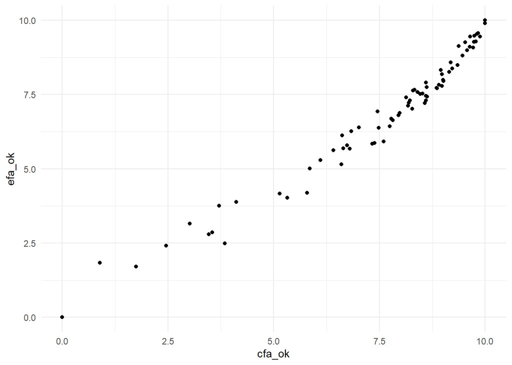

```r
ggplot(data=allData,aes(x=cfa_ok,y=efa_ok)) + geom_point() + theme_minimal()
```